# Project2

Sizar

4/12/2022

```r
require(dplyr)
require(knitr)
```

```r
require(mosaicData)
require(ggplot2)
require(mosaicData)
require(tidyr)
load("C:/Users/Mehedi Hasan Sizar/Desktop/Bennington College/Academics/Classes/Statistical Analysis/Project 2/Final/ICPSR_21600/DS0034/21600-0034-Data.rda")
load("C:/Users/Mehedi Hasan Sizar/Desktop/Bennington College/Academics/Classes/Statistical Analysis/Project 2/Final/ICPSR_21600/DS0035/21600-0035-Data.rda")
load("C:/Users/Mehedi Hasan Sizar/Desktop/Bennington College/Academics/Classes/Statistical Analysis/Project 2/Final/ICPSR_21600/DS0036/21600-0036-Data.rda")
load("C:/Users/Mehedi Hasan Sizar/Desktop/Bennington College/Academics/Classes/Statistical Analysis/Project 2/Final/ICPSR_21600/DS0037/21600-0037-Data.rda")
```

```r
V_Anthro<-da21600.0034%>%
  select(AID, H5HGT:H5BMI, H5HGTINS:H5BMICLS)

V_Cardio<-da21600.0035%>%
  select(AID, H5Q015, H5SBP:H5PP, H5Q045A:H5HTENJC)

V_Demog<-da21600.0036%>%
  select(AID:H5EXYEAR, H5AGE, H5Q011)

V_Glucose<-da21600.0037%>%
  select(AID, H5DIABJC)
```

```r
AddHealthV<-V_Anthro%>%
  inner_join(V_Cardio, by="AID")%>%
  inner_join(V_Demog, by="AID")%>%
  inner_join(V_Glucose, by="AID")
```

```r
AddHealthV <- AddHealthV %>%
  select(AID,H5EXMON,H5EXYEAR,H5AGE:H5Q011,H5HGT,H5WGT,H5BMI,H5BMICLS,H5Q015,H5Q045B,H5DIABJC,H5SBP,H5DBP,H5BPCLS4,H5BPCLS5,H5PR,H5PR,H5PP,H5Q045A:H5Q045F,H5AHT,H5HTENJC,everything())
```

```r
project2<-AddHealthV%>%
  select(AID,H5AGE,H5Q011,H5HGT,H5WGT,H5BMI,H5BMICLS,H5DIABJC,H5SBP,H5DBP,H5HTENJC,H5Q015)%>%
  filter(H5BMI<=50,H5SBP<=200,H5DBP<150)%>%
  rename(age=H5AGE,gender=H5Q011,height=H5HGT,weight=H5WGT,bmi=H5BMI,bmi_class=H5BMICLS,diabetes_class=H5DIABJC,systolicBP=H5SBP,diastolicBP=H5DBP,hypertension_class=H5HTENJC,smoking_status=H5Q015)
head(project2)
```

```
##        AID age gender height weight  bmi bmi_class diabetes_class systolicBP
## 1 57101310  42      2    182  123.4 37.3         5              1      128.0
## 2 57111786  37      1    180   89.5 27.6         3              0      116.5
## 3 57118381  34      2    171   66.2 22.6         2              0      117.0
## 4 57121404  39      2    155   59.1 24.6         2              0      122.5
## 5 57121476  36      2    162   76.0 29.0         3              0      105.0
## 6 57133772  37      2    166   53.7 19.5         2              0      109.0
##   diastolicBP hypertension_class smoking_status
## 1        84.5                  1              1
## 2        76.0                  0              0
## 3        70.5                  0              0
## 4        71.5                  0              0
## 5        65.0                  0              0
## 6        76.5                  0              0
```

# **Data Visualization:**

*#BMI vs Systolic BP:*

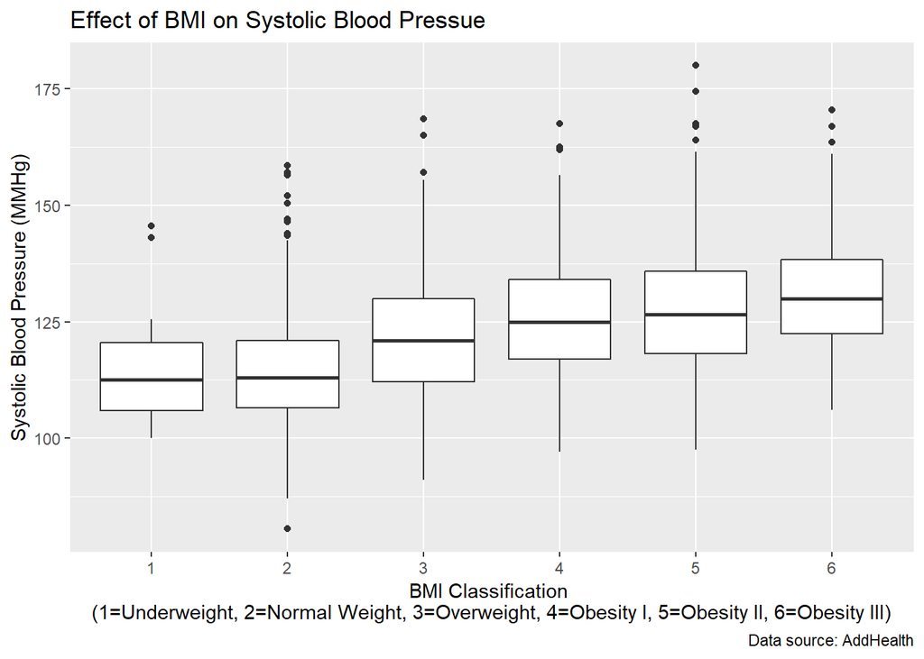

```r
bmibp<-project2%>%
  mutate(bmi_class=as.factor(bmi_class))

BMI_BP<-ggplot(bmibp, aes(x=bmi_class,y=systolicBP))+
  geom_boxplot()+ labs(x="BMI Classification
(1=Underweight, 2=Normal Weight, 3=Overweight, 4=Obesity I, 5=Obesity II, 6=Obesity III)", y="Systolic Blood Pressure (MMHg)", title = "Effect of BMI on Systolic Blood Pressue", caption = "Data source: AddHealth")
BMI_BP
```

```r
svg("C:/Users/Mehedi Hasan Sizar/Desktop/Bennington College/Academics/Classes/Statistical Analysis/Project 2/Final/Plots/BMI_BP.svg")

# Code of the plot
plot(BMI_BP)

# Close the graphics device
dev.off()
```

*#BMI & Diabetes:*

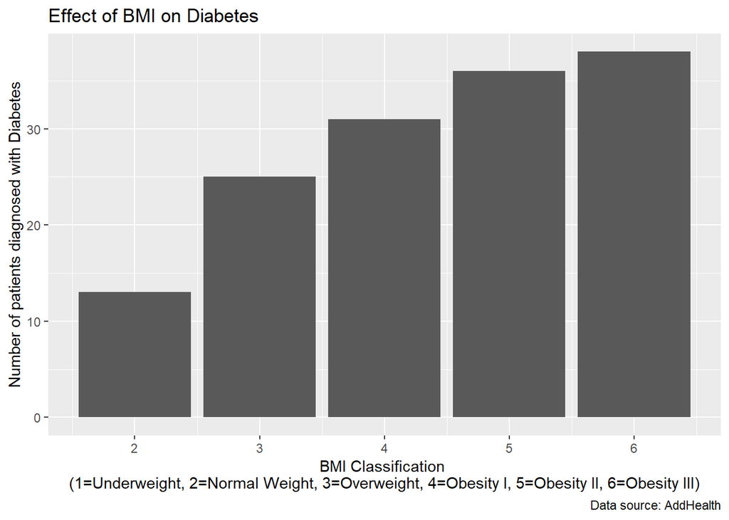

```r
db<-project2%>%
  filter(diabetes_class==1)

BMI_DB<-ggplot(db, aes(x=bmi_class))+
  geom_bar()+ labs(x="BMI Classification
(1=Underweight, 2=Normal Weight, 3=Overweight, 4=Obesity I, 5=Obesity II, 6=Obesity III)", y="Number of patients diagnosed with Diabetes", title = "Effect of BMI on Diabetes",
              caption = "Data source: AddHealth")

BMI_DB
```

```r
svg("C:/Users/Mehedi Hasan Sizar/Desktop/Bennington College/Academics/Classes/Statistical Analysis/Project 2/Final/Plots/BMI_DB.svg")

# Code of the plot
plot(BMI_DB)

# Close the graphics device
dev.off()
```

*#BMI & Diabetes:*

[figure not shown]

```r
df<-data.frame(BMI=c("Underweight","Normal","Overweight"), Diabetes=c(0,13,25), No_Diabetes=c(14,397,489))
bmiDiabetes_tbl<-gather(df, key = "Diabetes_status", value = "Count", 2:3)

BMI_DB2<-ggplot(bmiDiabetes_tbl, aes(x=BMI,y=Count,fill=Diabetes_status))+
  geom_bar(stat = "identity",position = "dodge")+ labs(x="BMI Class", y="Number of Patients", title = "Effect of BMI on getting Diabetes",
              caption = "Data source: AddHealth")

BMI_DB2
```

```r
svg("C:/Users/Mehedi Hasan Sizar/Desktop/Bennington College/Academics/Classes/Statistical Analysis/Project 2/Final/Plots/BMI_DB2.svg")

# Code of the plot
plot(BMI_DB2)

# Close the graphics device
dev.off()
```

*#Hypertension & Overweight:*

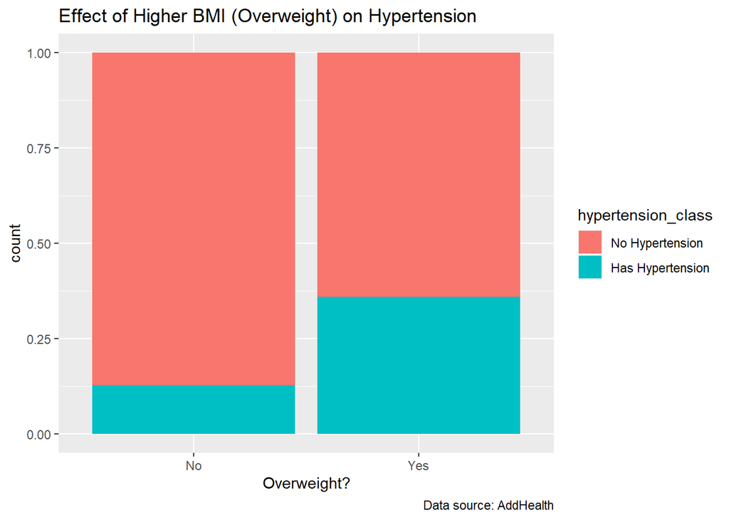

```r
dbpModel<-project2%>%
  mutate(overweight=(bmi_class>=3))%>%
  mutate(underweight=(bmi_class<2))%>%
  mutate(overweight=factor(overweight,labels=c("No","Yes")))%>%
  mutate(underweight=factor(underweight,labels=c("No","Yes")))%>%
  mutate(smoking_status=factor(smoking_status,labels=c("Doesn't Smoke","Smokes")))%>%
  mutate(diabetes_class=factor(diabetes_class,labels=c("No Diabetes","Has Diabetes")))%>%
  mutate(gender=factor(gender,labels=c("Male","Female")))%>%
  mutate(hypertension_class=factor(hypertension_class,labels=c("No Hypertension","Has Hypertension")))

HyperBMI<-ggplot(dbpModel, aes(x=overweight, fill=hypertension_class))+
  geom_bar(position = "fill")+ labs(x="Overweight?", title = "Effect of Higher BMI (Overweight) on Hypertension",
              caption = "Data source: AddHealth")

HyperBMI
```

```r
svg("C:/Users/Mehedi Hasan Sizar/Desktop/Bennington College/Academics/Classes/Statistical Analysis/Project 2/Final/Plots/HyperBMI.svg")

# Code of the plot
plot(HyperBMI)

# Close the graphics device
dev.off()
```

#### *#Systolic BP, BMI & Smoking Status:*

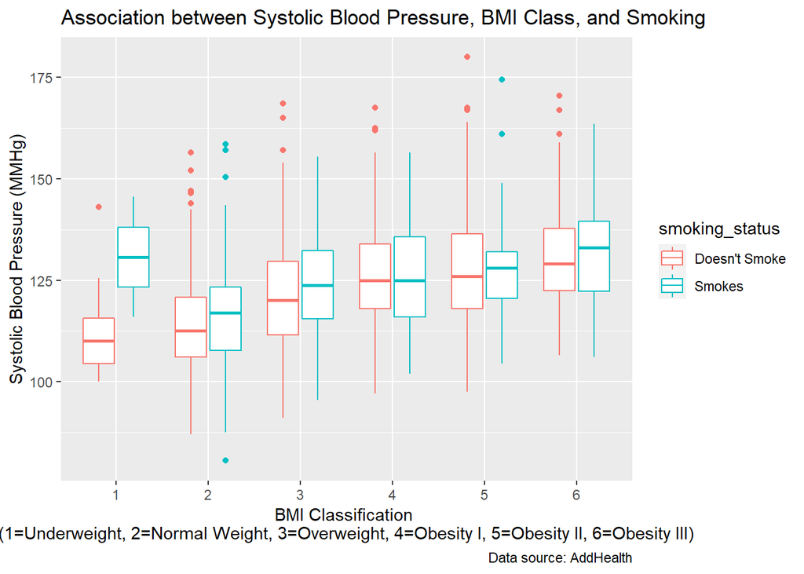

```r
dbpModel2<-dbpModel%>%
  mutate(bmi_class=as.factor(bmi_class))
SysBMISmo<-ggplot(dbpModel2, aes(x=bmi_class, y=systolicBP, color=smoking_status))+
  geom_boxplot()+ labs(x="BMI Classification
(1=Underweight, 2=Normal Weight, 3=Overweight, 4=Obesity I, 5=Obesity II, 6=Obesity III)",y="Systolic Blood Pressure (MMHg)", title = "Association between Systolic Blood Pressure, BMI Class, and Smoking",
              caption = "Data source: AddHealth")

SysBMISmo
```

```r
svg("C:/Users/Mehedi Hasan Sizar/Desktop/Bennington College/Academics/Classes/Statistical Analysis/Project 2/Final/Plots/SysBMISmo.svg")

# Code of the plot
plot(SysBMISmo)

# Close the graphics device
dev.off()
```

# **Test Results**

## **ANOVA**

#### *#Loading Dataset to perform ANOVA*

```r
anova<-project2%>%
  select(bmi_class,systolicBP)
anova$bmi_class <- as.factor(anova$bmi_class)
```

### **Question:** Does BMI (Underweight/Normal weight/Overweight) has any effect on Systolic Blood pressure?

Null Hypothesis, H<sub>0</sub> : The mean systolic blood pressure (MMHg) is the same in each type of BMI (1=Underweight, 2=Normal weight, 3=overweight).

Alternative Hypothesis, H<sub>A</sub> : At least people with one category of BMI has not the same mean systolic blood pressure (MMHg) as the others.

#### *#ANOVA Test*

```r
bp<- aov(systolicBP~bmi_class,data = anova)
summary(bp)
```

```
##               Df Sum Sq Mean Sq F value Pr(>F)
## bmi_class      5  49914    9983   59.86 <2e-16 ***
## Residuals   1706 284494     167
## ---
## Signif. codes:  0 '***' 0.001 '**' 0.01 '*' 0.05 '.' 0.1 ' ' 1
```

The Analysis of Variance (ANOVA) in the mean systolic blood pressure between different BMI categories suggests that there is a significant effect of BMI on average systolic blood pressure, F(5,1706)=59.86, p<0.001

#### *#Post-hoc ANOVA Test*

```r
TukeyHSD(bp)
```

```
##   Tukey multiple comparisons of means
##     95% family-wise confidence level
##
## Fit: aov(formula = systolicBP ~ bmi_class, data = anova)
##
## $bmi_class
##           diff         lwr       upr     p adj
## 2-1 -0.5919861 -10.6050829  9.421111 0.9999811
## 3-1  6.1385492  -3.8410436 16.118142 0.4955151
## 4-1 10.3306878   0.3036062 20.357769 0.0390516
## 5-1 12.7098583   2.5826506 22.837066 0.0047417
## 6-1 16.2694805   5.9852525 26.553709 0.0000995
## 3-2  6.7305353   4.2910178  9.170053 0.0000000
## 4-2 10.9226739   8.2956337 13.549714 0.0000000
## 5-2 13.3018444  10.3153231 16.288366 0.0000000
## 6-2 16.8614666  13.3794671 20.343466 0.0000000
## 4-3  4.1921386   1.6958408  6.688436 0.0000266
## 5-3  6.5713091   3.6991196  9.443499 0.0000000
## 6-3 10.1309313   6.7464841 13.515379 0.0000000
## 5-4  2.3791705  -0.6539083  5.412249 0.2209282
## 6-4  5.9387927   2.4167794  9.460806 0.0000241
## 6-5  3.5596222  -0.2380807  7.357325 0.0809939
```

#### **Conclusion:**

There is a significant difference in mean Systolic Blood Pressure between normal weight and overweight people (p<0.001), and on average overweight people have 6.73 MMHg higher blood pressure than people who have normal weight. However, the difference in the mean systolic blood pressure is not statistically significant between the overweight and underweight people (p=0.495) or underweight and normal weight people (p=0.999).

## **Logistic Regression**

#Change Factor Label:

```r
dbpModel<-project2%>%
  mutate(overweight=(bmi_class>=3))%>%
  mutate(underweight=(bmi_class<2))%>%
  mutate(overweight=factor(overweight,labels=c("No","Yes")))%>%
  mutate(underweight=factor(underweight,labels=c("No","Yes")))%>%
  mutate(smoking_status=factor(smoking_status,labels=c("Doesn't Smoke","Smokes")))%>%
  mutate(diabetes_class=factor(diabetes_class,labels=c("No Diabetes","Has Diabetes")))%>%
  mutate(gender=factor(gender,labels=c("Male","Female")))%>%
  mutate(hypertension_class=factor(hypertension_class,labels=c("No Hypertension","Has Hypertension")))
head(dbpModel)
```

```
##        AID age gender height weight  bmi bmi_class diabetes_class systolicBP
## 1 57101310  42 Female    182  123.4 37.3         5   Has Diabetes      128.0
## 2 57111786  37   Male    180   89.5 27.6         3    No Diabetes      116.5
## 3 57118381  34 Female    171   66.2 22.6         2    No Diabetes      117.0
## 4 57121404  39 Female    155   59.1 24.6         2    No Diabetes      122.5
## 5 57121476  36 Female    162   76.0 29.0         3    No Diabetes      105.0
## 6 57133772  37 Female    166   53.7 19.5         2    No Diabetes      109.0
##   diastolicBP hypertension_class smoking_status overweight underweight
## 1        84.5   Has Hypertension         Smokes        Yes          No
## 2        76.0    No Hypertension  Doesn't Smoke        Yes          No
## 3        70.5    No Hypertension  Doesn't Smoke         No          No
## 4        71.5    No Hypertension  Doesn't Smoke         No          No
## 5        65.0    No Hypertension  Doesn't Smoke        Yes          No
## 6        76.5    No Hypertension  Doesn't Smoke         No          No
```

### Can we predict the risk of being diagnosed with hypertensions of patiens by looking at their other health conditions (Age/Weight/Gender/Diseases/Smoking)?

Null Hypothesis, H<sub>0</sub> : There is no significant relationship between the risk of hypertension (response variable) and other health conditions (predictor variables).

Alternative Hypothesis, H<sub>A</sub> : There is a statistically significant relationship between the risk of hypertension (response variable) and other health conditions (predictor variables).

### *#Performing Logistic Regression*

#Hypertension & Overweight:

```r
fit<-glm(hypertension_class~overweight, data = dbpModel, family = "binomial")
summary(fit)
```

```
##
## Call:
## glm(formula = hypertension_class ~ overweight, family = "binomial",
##     data = dbpModel)
##
## Deviance Residuals:
##     Min       1Q   Median       3Q      Max
## -0.9439  -0.9439  -0.5220   1.4305   2.0301
##
## Coefficients:
##               Estimate Std. Error z value Pr(>|z|)
## (Intercept)    -1.9245     0.1457 -13.211   <2e-16 ***
## overweightYes   1.3469     0.1568   8.588   <2e-16 ***
## ---
## Signif. codes:  0 '***' 0.001 '**' 0.01 '*' 0.05 '.' 0.1 ' ' 1
##
## (Dispersion parameter for binomial family taken to be 1)
##
##     Null deviance: 2097.3  on 1711  degrees of freedom
## Residual deviance: 2005.8  on 1710  degrees of freedom
## AIC: 2009.8
##
## Number of Fisher Scoring iterations: 4
```

```r
fit$coefficients
```

```
##   (Intercept) overweightYes
##     -1.924519      1.346863
```

Counting the probability of having hypertension if a patient doesn’t have overweight:

```r
1/(1+exp(-fit$coefficients[1]))
```

```
## (Intercept)
##   0.1273585
```

Counting the probability of having hypertension if a patient has overweight:

```r
1/(1+exp(-fit$coefficients[1]-fit$coefficients[2]*1))
```

```
## (Intercept)
##    0.359472
```

Hence, the model tells that, the probability of a patient being diagnosed with hypertension if the patient doesn’t have overweight is 0.127, and the probability of a patient being diagnosed with hypertension if the patient has overweight is 0.359. Which means, to filter out the patients with hypertension only looking at the overweight status is not sufficient (36% of the time), and we need to find a better model involving more variables.

#Adding more predictor variables:

```r
fit<-glm(hypertension_class~overweight+underweight+smoking_status+diabetes_class+gender, data = dbpModel, family = "binomial")
summary(fit)
```

```
##
## Call:
## glm(formula = hypertension_class ~ overweight + underweight +
##     smoking_status + diabetes_class + gender, family = "binomial",
##     data = dbpModel)
##
## Deviance Residuals:
##     Min       1Q   Median       3Q      Max
## -1.7465  -0.8901  -0.7066   1.1859   2.2121
##
## Coefficients:
##                            Estimate Std. Error z value Pr(>|z|)
## (Intercept)                 -1.6546     0.1685  -9.819  < 2e-16 ***
## overweightYes                1.2405     0.1626   7.631 2.33e-14 ***
## underweightYes               0.2423     0.7893   0.307  0.75890
## smoking_statusSmokes         0.3941     0.1282   3.074  0.00211 **
## diabetes_classHas Diabetes   1.2996     0.1874   6.936 4.05e-12 ***
## genderFemale                -0.7016     0.1123  -6.248 4.14e-10 ***
## ---
## Signif. codes:  0 '***' 0.001 '**' 0.01 '*' 0.05 '.' 0.1 ' ' 1
##
## (Dispersion parameter for binomial family taken to be 1)
##
##     Null deviance: 2097.3  on 1711  degrees of freedom
## Residual deviance: 1908.0  on 1706  degrees of freedom
## AIC: 1920
##
## Number of Fisher Scoring iterations: 4
```

Removing underweight from the model, since it has the highest p-value:

```r
fit<-glm(hypertension_class~overweight+smoking_status+diabetes_class+gender, data = dbpModel, family = "binomial")
summary(fit)
```

```
##
## Call:
## glm(formula = hypertension_class ~ overweight + smoking_status +
##     diabetes_class + gender, family = "binomial", data = dbpModel)
##
## Deviance Residuals:
##    Min      1Q  Median      3Q     Max
## -1.746  -0.890  -0.709   1.186   2.209
##
## Coefficients:
##                            Estimate Std. Error z value Pr(>|z|)
## (Intercept)                 -1.6463     0.1660  -9.920  < 2e-16 ***
## overweightYes                1.2324     0.1600   7.702 1.34e-14 ***
## smoking_statusSmokes         0.3937     0.1282   3.071  0.00213 **
## diabetes_classHas Diabetes   1.2988     0.1873   6.933 4.11e-12 ***
## genderFemale                -0.7015     0.1123  -6.248 4.15e-10 ***
## ---
## Signif. codes:  0 '***' 0.001 '**' 0.01 '*' 0.05 '.' 0.1 ' ' 1
##
## (Dispersion parameter for binomial family taken to be 1)
##
##     Null deviance: 2097.3  on 1711  degrees of freedom
## Residual deviance: 1908.1  on 1707  degrees of freedom
## AIC: 1918.1
##
## Number of Fisher Scoring iterations: 4
```

Here, all the variables that are left have coefficients that are significantly different from 0 at the α = 0.01 significance level.

### **Conclusion:**

The resulting model:

$logit(p)=e^{-1.646+1.232*overweight_{yes}+0.394*smoking\_status_{smokes}+1.299*diabetes\_class_{has diabetes}-0.702*gender_{female}}$

The odds ratios are:

```r
exp(fit$coefficients)
```

```
##                (Intercept)              overweightYes
##                  0.1927590                  3.4294882
##       smoking_statusSmokes diabetes_classHas Diabetes
##                  1.4825251                  3.6647928
##               genderFemale
##                  0.4958178
```

These odds ratios tell us that the patients are most likely to be diagnosed with hypertension are those who have overweights, have been smoking, have been diagnosed with Diabetes previously, and who are not female in gender.

#Calculating the efficiency of the model to interpret whether a patient is at risk of being diagnosed with hypertension:

```r
1/(1+exp(-(-1.646+1.232+0.394+1.299)))
```

```
## [1] 0.7822795
```

## **Linear Regression**

#### *#Loading Dataset to perform Linear Regression*

```r
bp_sample<-project2[sample.int(n=length(project2$systolicBP), size = 50, replace = FALSE),]
head(bp_sample)
```

```
##           AID age gender height weight  bmi bmi_class diabetes_class systolicBP
## 1022 96506274  38      2  166.0   74.9 27.2         3              0      123.0
## 1241 97573957  38      1  175.0   74.2 24.2         2              0      104.5
## 1329 97716162  37      1  182.0  118.0 35.6         5              0      153.0
## 1014 96500221  37      2  165.5   67.3 24.6         2              0      120.0
## 554  93572346  37      2  160.0   89.9 35.1         5              0      127.5
## 1060 96573436  40      2  164.5   87.8 32.4         4              0      112.5
##      diastolicBP hypertension_class smoking_status
## 1022        79.0                  0              0
## 1241        69.0                  0              0
## 1329        96.5                  1              0
## 1014        78.5                  0              1
## 554         92.0                  1              0
## 1060        71.0                  0              0
```

### **Question:** Does Systolic Blood Pressure have any effect on Diastolic Blood Pressure?

Null Hypothesis, H<sub>0</sub> : There is no relationship between systolic and diastolic blood pressure (Correlation Coefficient, r=0).

Alternative Hypothesis, H<sub>A</sub> : There is a relationship between systolic and diastolic blood pressure (r≠0).

#### *#Finding the coefficient correlation, r:*

```r
cor(bp_sample$systolicBP,bp_sample$diastolicBP)
```

```
## [1] 0.9012948
```

#### *#Performing Linear Regression*

```r
bp_fit<-lm(diastolicBP~systolicBP, data = bp_sample)
summary(bp_fit)
```

```
##
## Call:
## lm(formula = diastolicBP ~ systolicBP, data = bp_sample)
##
## Residuals:
##     Min      1Q  Median      3Q     Max
## -9.5243 -2.9047 -0.7368  3.2118 10.1070
##
## Coefficients:
##             Estimate Std. Error t value Pr(>|t|)
## (Intercept)  5.10579    5.05338    1.01    0.317
## systolicBP   0.60225    0.04178   14.41   <2e-16 ***
## ---
## Signif. codes:  0 '***' 0.001 '**' 0.01 '*' 0.05 '.' 0.1 ' ' 1
##
## Residual standard error: 4.602 on 48 degrees of freedom
## Multiple R-squared:  0.8123, Adjusted R-squared:  0.8084
## F-statistic: 207.8 on 1 and 48 DF,  p-value: < 2.2e-16
```

*#Data Visualization:*

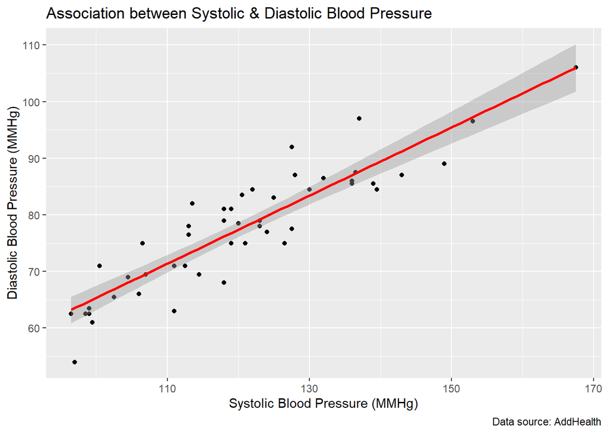

```r
SysDia<-ggplot(bp_fit$model, aes_string(x=names(bp_fit$model)[2],y=names(bp_fit$model)[1]))+
  geom_point()+ stat_smooth(method = "lm", col = "red")+ labs(x="Systolic Blood Pressure (MMHg)",y="Diastolic Blood Pressure (MMHg)", title = "Association between Systolic & Diastolic Blood Pressure",
              caption = "Data source: AddHealth")

SysDia
```

```r
svg("C:/Users/Mehedi Hasan Sizar/Desktop/Bennington College/Academics/Classes/Statistical Analysis/Project 2/Final/Plots/SysDia1.svg")

# Code of the plot
plot(SysDia)
# Close the graphics device
dev.off()
```

## **Chi-square test**

#### *#Loading Dataset to perform Chi-square test*

```r
chisq<-project2%>%
  mutate(bmi_class = case_when(bmi_class == 1 ~ 'underweight',
                           bmi_class == 2 ~ 'normal weight',
                           bmi_class >= 3 ~ 'overweight'))%>%
  select(bmi_class,diabetes_class)
chisq$bmi_class <- as.factor(chisq$bmi_class)
chisq$diabetes_class <- as.factor(chisq$diabetes_class)
head(chisq)
```

```
##       bmi_class diabetes_class
## 1    overweight              1
## 2    overweight              0
## 3 normal weight              0
## 4 normal weight              0
## 5    overweight              0
## 6 normal weight              0
```

#### *#Forming a two-way table*

```r
bmiDiabetes <- chisq %>%
  group_by(bmi_class,diabetes_class)%>%
  summarise(n=n())%>%
spread(diabetes_class,n)
bmiDiabetes[is.na(bmiDiabetes)]=0
bmiDiabetes
```

```
## # A tibble: 3 x 3
## # Groups:   bmi_class [3]
##   bmi_class       `0`   `1`
##   <fct>         <int> <int>
## 1 normal weight   397    13
## 2 overweight     1158   130
## 3 underweight      14     0
```

### **Question:** Does BMI (Underweight/Overweight) has any effect on having Diabetes?

Null Hypothesis, H<sub>0</sub> : There is no relationship between BMI (Overweight or not overweight) and whether or not ever has diagnosed with diabetes (diabetes_class: 0=No diabetes, 1=Has diabetes).

Alternative Hypothesis, H<sub>A</sub> : There is a relationship between BMI categories and whether or not has ever diagnosed with diabetes.

#### *#Forming Data Table*

```r
df<-data.frame(BMI=c("Normal Weight", "Overweight", "Underweight"), Diabetes=c(13,130,0), No_Diabetes=c(397,1158,14))
bmiDiabetes_tbl<-gather(df, key = "Diabetes_status", value = "Count", 2:3)
bmiDiabetes_tbl
```

```
##             BMI Diabetes_status Count
## 1 Normal Weight        Diabetes    13
## 2    Overweight        Diabetes   130
## 3   Underweight        Diabetes     0
## 4 Normal Weight     No_Diabetes   397
## 5    Overweight     No_Diabetes  1158
## 6   Underweight     No_Diabetes    14
```

```r
chisq.test(bmiDiabetes$`1`,bmiDiabetes$overweight, correct = F)
```

```
##
##  Chi-squared test for given probabilities
##
## data:  bmiDiabetes$`1`
## X-squared = 215.09, df = 2, p-value < 2.2e-16
```

### *#Performing Logistic Regression*

#Change Factor Label:

```r
dbpModel2<-project2%>%
  mutate(overweight=(bmi_class>=3))%>%
  mutate(underweight=(bmi_class<2))%>%
  mutate(overweight=factor(overweight,labels=c("No","Yes")))%>%
  mutate(underweight=factor(underweight,labels=c("No","Yes")))%>%
  mutate(smoking_status=factor(smoking_status,labels=c("Doesn't Smoke","Smokes")))%>%
  mutate(diabetes_class=factor(diabetes_class,labels=c("No Diabetes","Has Diabetes")))%>%
  mutate(gender=factor(gender,labels=c("Male","Female")))%>%
  mutate(hypertension_class=factor(hypertension_class,labels=c("No Hypertension","Has Hypertension")))
head(dbpModel2)
```

```
##        AID age gender height weight  bmi bmi_class diabetes_class systolicBP
## 1 57101310  42 Female    182  123.4 37.3         5   Has Diabetes      128.0
## 2 57111786  37   Male    180   89.5 27.6         3    No Diabetes      116.5
## 3 57118381  34 Female    171   66.2 22.6         2    No Diabetes      117.0
## 4 57121404  39 Female    155   59.1 24.6         2    No Diabetes      122.5
## 5 57121476  36 Female    162   76.0 29.0         3    No Diabetes      105.0
## 6 57133772  37 Female    166   53.7 19.5         2    No Diabetes      109.0
##   diastolicBP hypertension_class smoking_status overweight underweight
## 1        84.5   Has Hypertension         Smokes        Yes          No
## 2        76.0    No Hypertension  Doesn't Smoke        Yes          No
## 3        70.5    No Hypertension  Doesn't Smoke         No          No
## 4        71.5    No Hypertension  Doesn't Smoke         No          No
## 5        65.0    No Hypertension  Doesn't Smoke        Yes          No
## 6        76.5    No Hypertension  Doesn't Smoke         No          No
```

#Diabetes & Overweight:

```r
fit2<-glm(diabetes_class~overweight, data = dbpModel2, family = "binomial")
summary(fit2)
```

```
##
## Call:
## glm(formula = diabetes_class ~ overweight, family = "binomial",
##     data = dbpModel2)
##
## Deviance Residuals:
##     Min       1Q   Median       3Q      Max
## -0.4613  -0.4613  -0.4613  -0.2496   2.6400
##
## Coefficients:
##               Estimate Std. Error z value Pr(>|z|)
## (Intercept)    -3.4536     0.2817 -12.260  < 2e-16 ***
## overweightYes   1.2667     0.2965   4.272 1.93e-05 ***
## ---
## Signif. codes:  0 '***' 0.001 '**' 0.01 '*' 0.05 '.' 0.1 ' ' 1
##
## (Dispersion parameter for binomial family taken to be 1)
##
##     Null deviance: 983.72  on 1711  degrees of freedom
## Residual deviance: 958.88  on 1710  degrees of freedom
## AIC: 962.88
##
## Number of Fisher Scoring iterations: 6
```

```r
fit2$coefficients
```

```
##   (Intercept) overweightYes
##     -3.453644      1.266729
```

Counting the probability of having Diabetes if a patient doesn’t have overweight:

```r
1/(1+exp(-fit2$coefficients[1]))
```

```
## (Intercept)
##  0.03066038
```

Counting the probability of having Diabetes if a patient has overweight:

```r
1/(1+exp(-fit2$coefficients[1]-fit2$coefficients[2]*1))
```

```
## (Intercept)
##   0.1009317
```

#Adding more predictor variables:

```r
fit2<-glm(diabetes_class~overweight+underweight+smoking_status+gender+hypertension_class, data = dbpModel2, family = "binomial")
summary(fit2)
```

```
##
## Call:
## glm(formula = diabetes_class ~ overweight + underweight + smoking_status +
##     gender + hypertension_class, family = "binomial", data = dbpModel2)
##
## Deviance Residuals:
##     Min       1Q   Median       3Q      Max
## -0.6742  -0.3677  -0.3325  -0.2367   2.8513
##
## Coefficients:
##                                    Estimate Std. Error z value Pr(>|z|)
## (Intercept)                         -3.7688     0.3236 -11.646  < 2e-16 ***
## overweightYes                        0.9009     0.3039   2.964  0.00304 **
## underweightYes                     -12.1697   381.8437  -0.032  0.97457
## smoking_statusSmokes                -0.2790     0.2219  -1.258  0.20855
## genderFemale                         0.2076     0.1859   1.116  0.26422
## hypertension_classHas Hypertension   1.2944     0.1869   6.927  4.3e-12 ***
## ---
## Signif. codes:  0 '***' 0.001 '**' 0.01 '*' 0.05 '.' 0.1 ' ' 1
##
## (Dispersion parameter for binomial family taken to be 1)
##
##     Null deviance: 983.72  on 1711  degrees of freedom
## Residual deviance: 907.88  on 1706  degrees of freedom
## AIC: 919.88
##
## Number of Fisher Scoring iterations: 14
```

Removing underweight from the model, since it has the highest p-value:

```r
fit2<-glm(diabetes_class~overweight+smoking_status+hypertension_class+gender, data = dbpModel2, family = "binomial")
summary(fit2)
```

```
##
## Call:
## glm(formula = diabetes_class ~ overweight + smoking_status +
##     hypertension_class + gender, family = "binomial", data = dbpModel2)
##
## Deviance Residuals:
##     Min       1Q   Median       3Q      Max
## -0.6739  -0.3676  -0.3326  -0.2324   2.8635
##
## Coefficients:
##                                    Estimate Std. Error z value Pr(>|z|)
## (Intercept)                         -3.8049     0.3236 -11.759  < 2e-16 ***
## overweightYes                        0.9376     0.3037   3.087  0.00202 **
## smoking_statusSmokes                -0.2781     0.2219  -1.253  0.21008
## hypertension_classHas Hypertension   1.2937     0.1868   6.925 4.36e-12 ***
## genderFemale                         0.2069     0.1859   1.113  0.26584
## ---
## Signif. codes:  0 '***' 0.001 '**' 0.01 '*' 0.05 '.' 0.1 ' ' 1
##
## (Dispersion parameter for binomial family taken to be 1)
##
##     Null deviance: 983.72  on 1711  degrees of freedom
## Residual deviance: 908.81  on 1707  degrees of freedom
## AIC: 918.81
##
## Number of Fisher Scoring iterations: 6
```

Removing gender from the model, since it has the highest p-value:

```r
fit2<-glm(diabetes_class~overweight+hypertension_class+smoking_status, data = dbpModel2, family = "binomial")
summary(fit2)
```

```
##
## Call:
## glm(formula = diabetes_class ~ overweight + hypertension_class +
##     smoking_status, family = "binomial", data = dbpModel2)
##
## Deviance Residuals:
##     Min       1Q   Median       3Q      Max
## -0.6443  -0.3642  -0.3560  -0.2262   2.8140
##
## Coefficients:
##                                    Estimate Std. Error z value Pr(>|z|)
## (Intercept)                         -3.6527     0.2917 -12.521  < 2e-16 ***
## overweightYes                        0.9259     0.3034   3.052  0.00228 **
## hypertension_classHas Hypertension   1.2600     0.1841   6.843 7.77e-12 ***
## smoking_statusSmokes                -0.2873     0.2216  -1.296  0.19482
## ---
## Signif. codes:  0 '***' 0.001 '**' 0.01 '*' 0.05 '.' 0.1 ' ' 1
##
## (Dispersion parameter for binomial family taken to be 1)
##
##     Null deviance: 983.72  on 1711  degrees of freedom
## Residual deviance: 910.06  on 1708  degrees of freedom
## AIC: 918.06
##
## Number of Fisher Scoring iterations: 6
```

Removing smoking status from the model, since it has the highest p-value:

```r
fit2<-glm(diabetes_class~overweight+hypertension_class, data = dbpModel2, family = "binomial")
summary(fit2)
```

```
##
## Call:
## glm(formula = diabetes_class ~ overweight + hypertension_class,
##     family = "binomial", data = dbpModel2)
##
## Deviance Residuals:
##     Min       1Q   Median       3Q      Max
## -0.6236  -0.4023  -0.3470  -0.2194   2.7344
##
## Coefficients:
##                                    Estimate Std. Error z value Pr(>|z|)
## (Intercept)                         -3.7144     0.2889 -12.857  < 2e-16 ***
## overweightYes                        0.9345     0.3031   3.083  0.00205 **
## hypertension_classHas Hypertension   1.2409     0.1832   6.772 1.27e-11 ***
## ---
## Signif. codes:  0 '***' 0.001 '**' 0.01 '*' 0.05 '.' 0.1 ' ' 1
##
## (Dispersion parameter for binomial family taken to be 1)
##
##     Null deviance: 983.72  on 1711  degrees of freedom
## Residual deviance: 911.82  on 1709  degrees of freedom
## AIC: 917.82
##
## Number of Fisher Scoring iterations: 6
```

Here, all the variables that are left have coefficients that are significantly different from 0 at the α = 0.01 significance level.

### **Conclusion:**

The resulting model:

The odds ratios are:

```r
exp(fit2$coefficients)
```

```
##                        (Intercept)                      overweightYes
##                         0.02436994                         2.54601405
## hypertension_classHas Hypertension
##                         3.45860091
```

These odds ratios tell us that the patients are most likely to be diagnosed with Diabetes are those who have overweights, and have been diagnosed with Hypertension previously.